# Final Submission

Spotify songs database

Miklos Bognar

2021-01-16

# Spotify songs data analysis

## Preparations

### Loading packages

```r
library(tidyverse)
library(tidytuesdayR)
library(ggpubr)
library(olsrr)
library(car)
library(jtools)
theme_set(theme_light())
```

### Loading data

```r
source_data = tt_load("2020-01-21")$spotify_songs
```

## Hypothesis

There is a popular assumption that the key of certain melodies (major or minor) define the happiness of these melodies. In this dataset there is a numerical value called **valence** which determines the valence of each songs. I am going to test if keys ( **mode** ) predict the overall valence of songs on this dataset. I am also planning to include a more complex model with two other predicting variables **tempo** and **energy**, as I *assume* that these variables also play a role in defining a song’s overall valence.

## About the dataset

The dataset is a collection of spotify songs recieved with the spotify API. The detailed values of - seemingly - subjective variables got my attention about the data collection method. It is not a surprise that the present data is a product of a proprietary algorithm developed by [The Echo Nest company](https://en.wikipedia.org/wiki/The_Echo_Nest) which provided digital signal processing services and released data on 1 million songs for research purposes. There is not much information about the method of estimating these variables but we can assume that a machine learning algorithm was trained on subjective data, and this algorithm is responsible for these ratings. The Echo Nest however was aquired by Spotify in 2014 and their algorithm and data was merged into spotify’s product personalization service. Capitalism vs. music psychology: 1-0. But hey, we got this fancy dataset to analyze…

## Data wrangling

I recode mode as “major” and “minor” to make sure it is handled as a categorical variable

```r
source_data <- source_data %>%
  mutate(mode = case_when(
    mode == 1 ~ "major",
    TRUE ~ "minor"
  ))
```

## Exploring the data

Descriptive data of valence grouped by mode

```r
desc_table <- source_data %>%
  group_by(mode) %>%
  summarize(mean(valence), median(valence), sd(valence))

desc_table
```

```
## # A tibble: 2 x 4
##   mode  `mean(valence)` `median(valence)` `sd(valence)`
##   <chr>           <dbl>             <dbl>         <dbl>
## 1 major           0.511             0.513         0.233
## 2 minor           0.510             0.512         0.233
```

```r
#Oh, this doesn't look too good...
```

Checking distribution of predicted and predicting variables

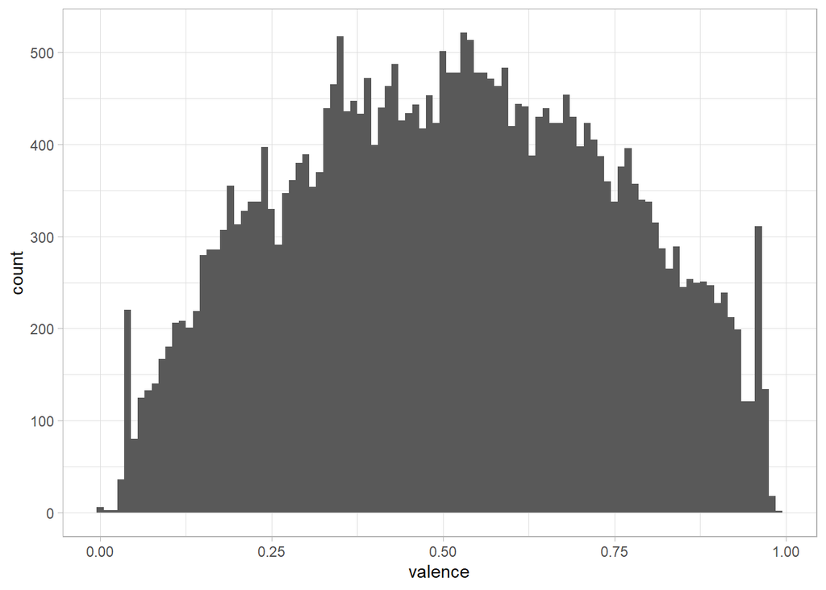

```r
# VALENCE
source_data %>% ggplot(aes(valence)) + geom_histogram(binwidth = 0.01)
```

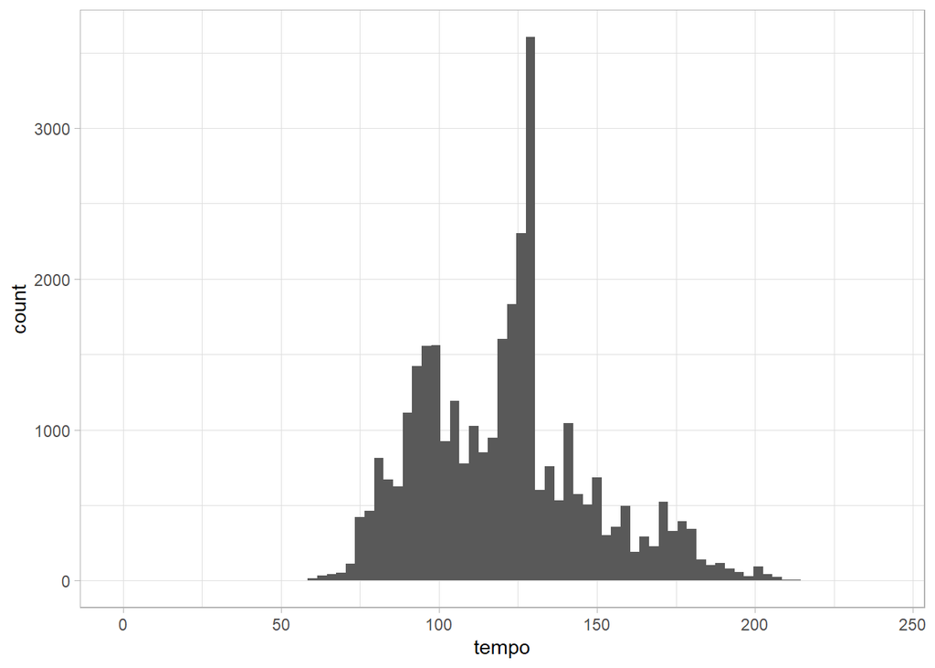

```r
# TEMPO
source_data %>% ggplot(aes(tempo)) + geom_histogram(binwidth = 3)
```

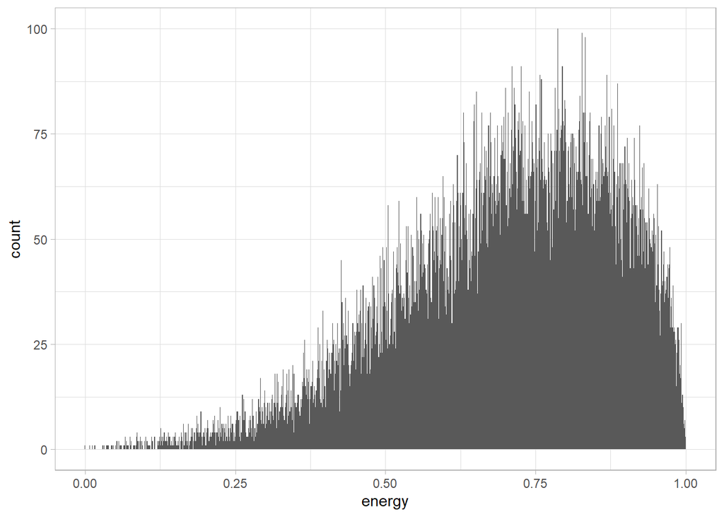

```r
# ENERGY
source_data %>% ggplot(aes(energy)) + geom_histogram(binwidth = 0.001)
```

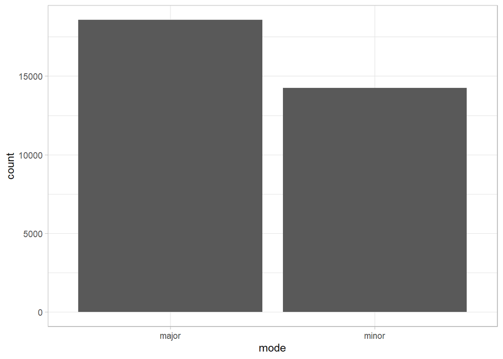

```r
# MODE
source_data %>% ggplot(aes(mode)) + geom_bar()
```

## Creating complex model

```r
complex_model = lm(valence ~mode + energy + tempo, data = source_data)
summary(complex_model)
```

```
##
## Call:
## lm(formula = valence ~ mode + energy + tempo, data = source_data)
##
## Residuals:
##      Min       1Q   Median       3Q      Max
## -0.57914 -0.17681  0.00094  0.17789  0.58429
##
## Coefficients:
##               Estimate Std. Error t value Pr(>|t|)
## (Intercept)  4.206e-01  7.234e-03  58.134   <2e-16 ***
## modeminor   -1.922e-03  2.563e-03  -0.750    0.453
## energy       2.043e-01  7.103e-03  28.768   <2e-16 ***
## tempo       -4.295e-04  4.777e-05  -8.992   <2e-16 ***
## ---
## Signif. codes:  0 '***' 0.001 '**' 0.01 '*' 0.05 '.' 0.1 ' ' 1
##
## Residual standard error: 0.2302 on 32829 degrees of freedom
## Multiple R-squared:  0.02524,    Adjusted R-squared:  0.02516
## F-statistic: 283.4 on 3 and 32829 DF,  p-value: < 2.2e-16
```

## Checking for influential outliers and assumptions

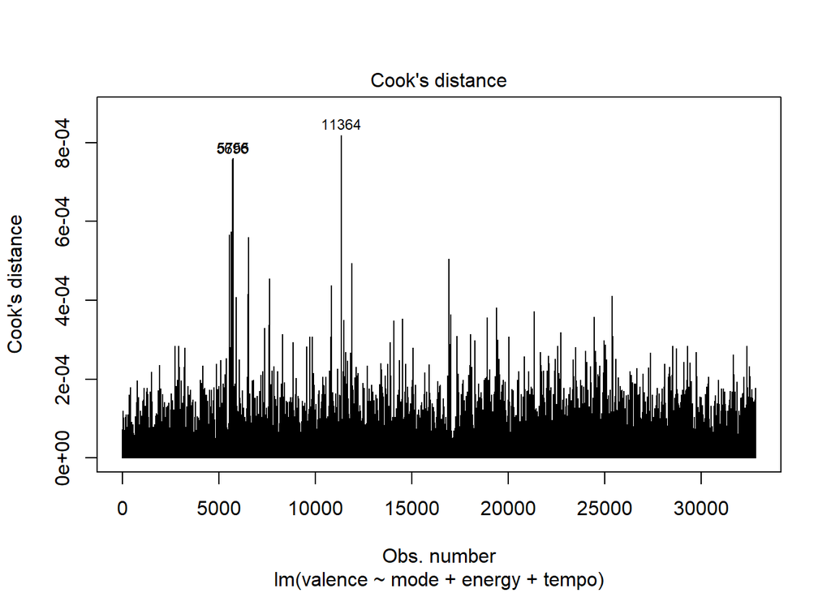

```r
plot(complex_model, 4)
```

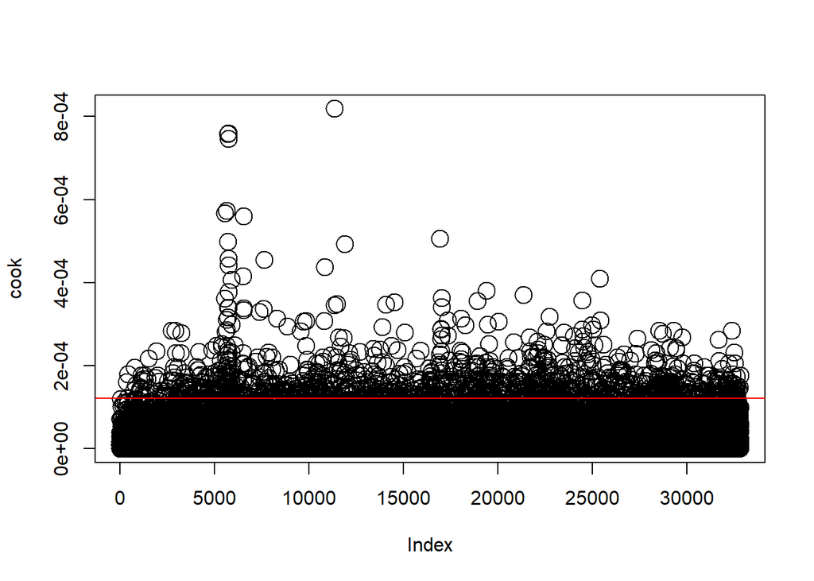

```
## integer(0)
```

```r
cook <- cooks.distance(complex_model)
samplesize <- nrow(source_data)
plot(cook, cex=2) + abline(h=4/samplesize, col="red")
```

```r
outliers = as.numeric(names(cook)[(cook>(4/samplesize))])

cleaned_data = source_data[-outliers,]
```

I created a cleaned_data dataframe without the influential outliers

### Normality

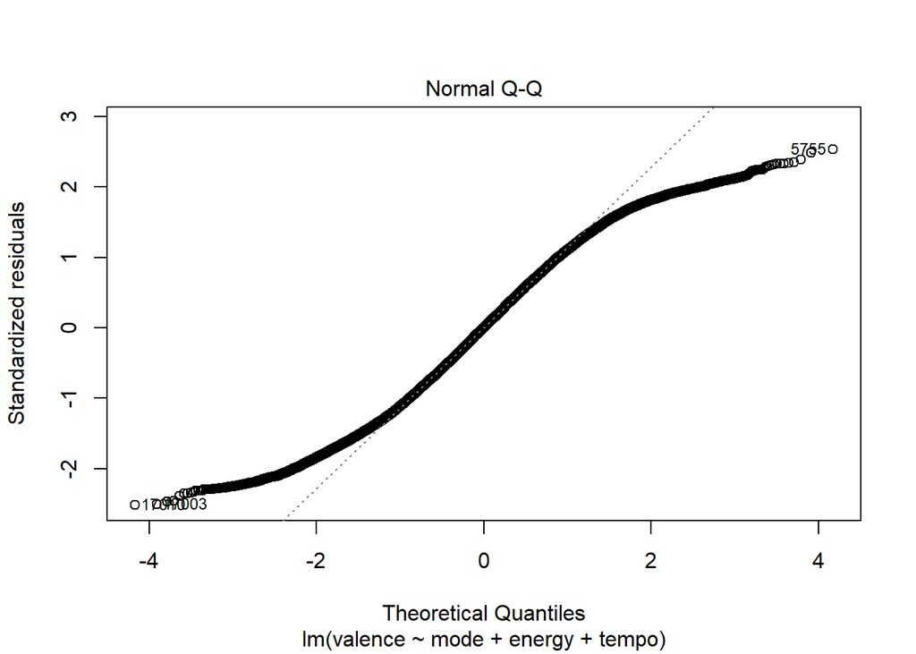

```r
plot(complex_model,2)
```

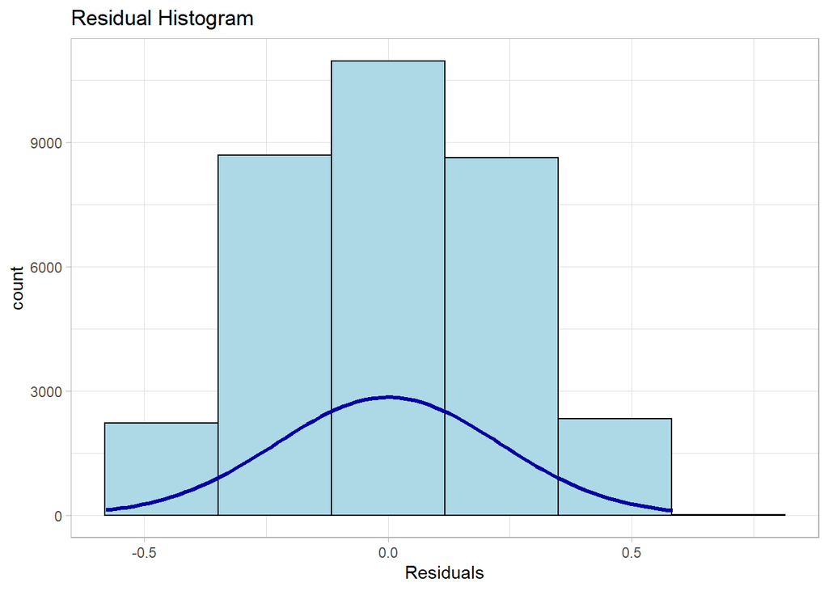

```r
ols_plot_resid_hist(complex_model)
```

### Linearity

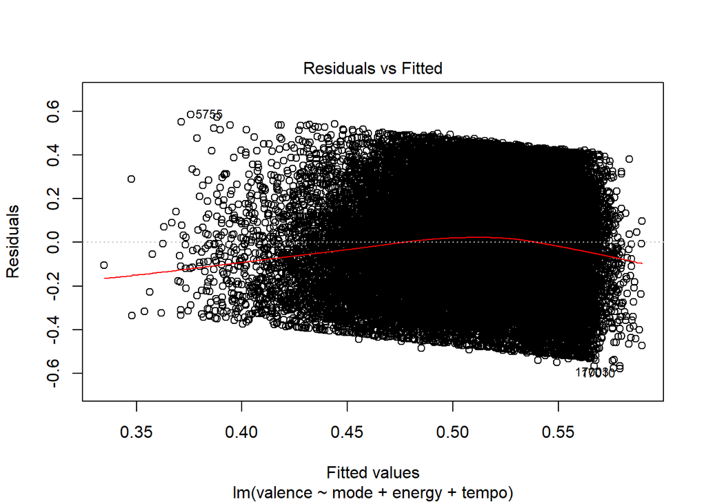

```r
#linearity
plot(complex_model,1)
```

### Homogenity of variance

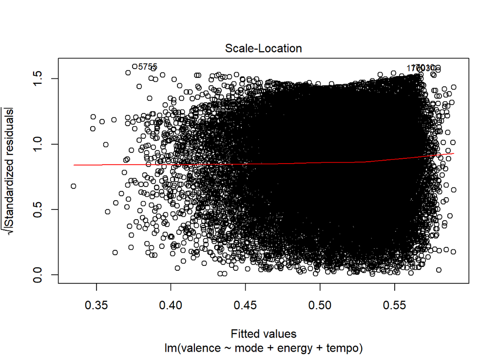

```r
#homogenity of variance
plot(complex_model,3)
```

### Multicollinearity

```r
#multicollinearity
vif(complex_model)
```

```
##     mode   energy    tempo
## 1.000255 1.023053 1.023240
```

## Creating the updated complex model on the cleaned data

```r
updated_complex_model <- lm(valence ~ mode + energy + tempo, data = cleaned_data)
summary(updated_complex_model)
```

```
##
## Call:
## lm(formula = valence ~ mode + energy + tempo, data = cleaned_data)
##
## Residuals:
##     Min      1Q  Median      3Q     Max
## -0.5220 -0.1701  0.0011  0.1709  0.5024
##
## Coefficients:
##               Estimate Std. Error t value Pr(>|t|)
## (Intercept)  4.406e-01  7.276e-03  60.562   <2e-16 ***
## modeminor   -3.062e-03  2.504e-03  -1.223    0.221
## energy       2.280e-01  7.158e-03  31.856   <2e-16 ***
## tempo       -7.191e-04  4.833e-05 -14.879   <2e-16 ***
## ---
## Signif. codes:  0 '***' 0.001 '**' 0.01 '*' 0.05 '.' 0.1 ' ' 1
##
## Residual standard error: 0.2209 on 31733 degrees of freedom
## Multiple R-squared:  0.03403,    Adjusted R-squared:  0.03394
## F-statistic: 372.7 on 3 and 31733 DF,  p-value: < 2.2e-16
```

### Checking Normality

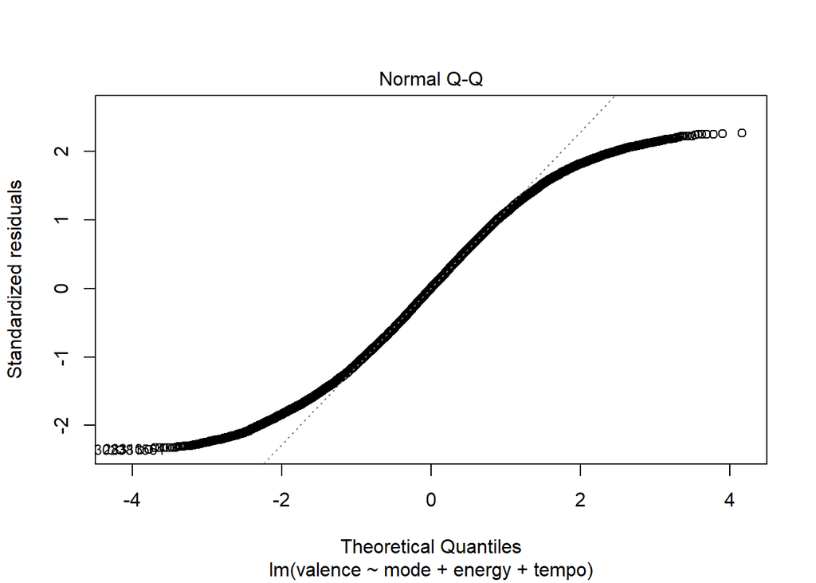

```r
plot(updated_complex_model, 2)
```

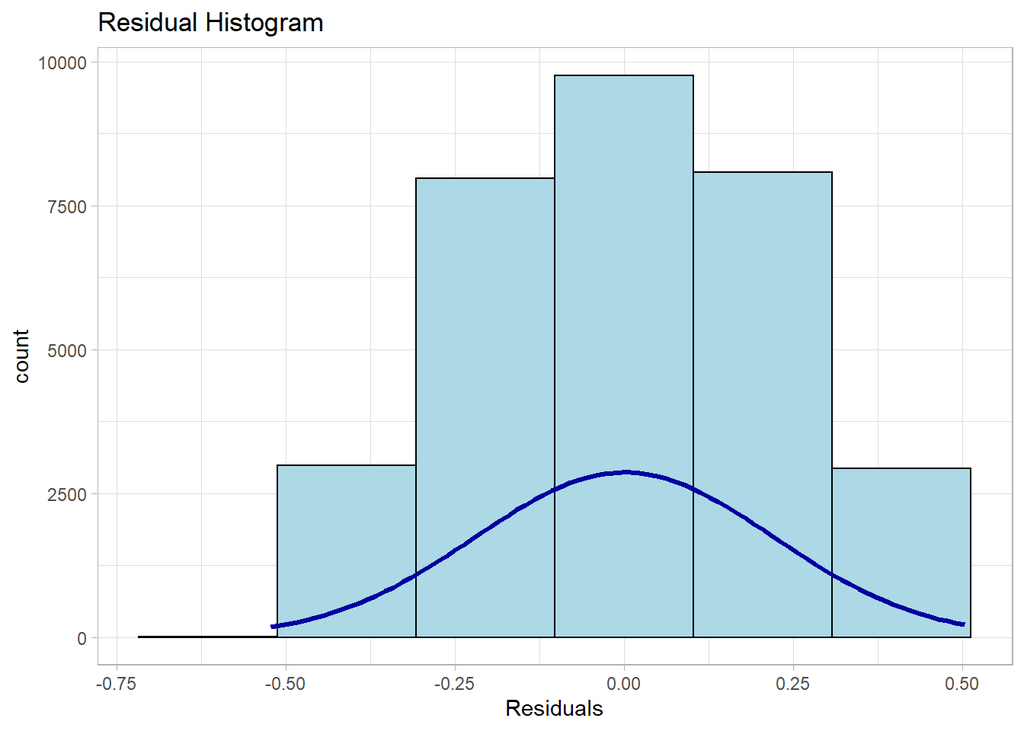

```r
ols_plot_resid_hist(updated_complex_model)
```

### Linearity

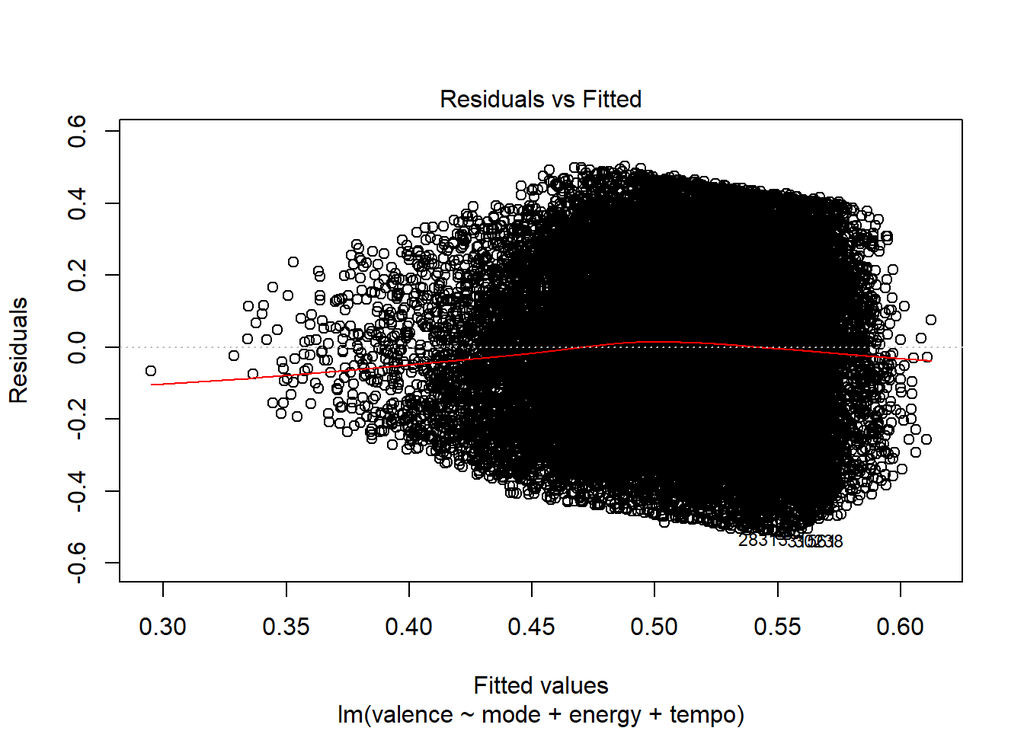

```r
#linearity

plot(updated_complex_model,1)
```

### Homogenity of variance

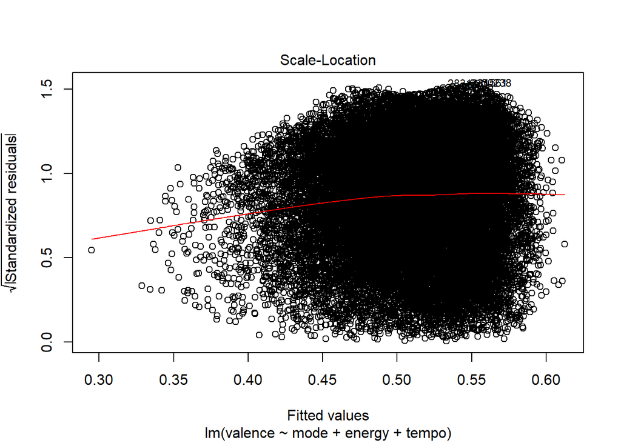

```r
#homogenity of variance

plot(updated_complex_model,3)
```

### Milticollinearity

```r
#multicollinearity

vif(updated_complex_model)
```

```
##     mode   energy    tempo
## 1.000290 1.024044 1.024307
```

No changes needed after the updated model

## Creating the simple model

```r
simple_model <- lm(valence ~ mode, data = cleaned_data)
summary(simple_model)
```

```
##
## Call:
## lm(formula = valence ~ mode, data = cleaned_data)
##
## Residuals:
##     Min      1Q  Median      3Q     Max
## -0.4980 -0.1749  0.0004  0.1754  0.4772
##
## Coefficients:
##              Estimate Std. Error t value Pr(>|t|)
## (Intercept)  0.513848   0.001675 306.804   <2e-16 ***
## modeminor   -0.002246   0.002547  -0.882    0.378
## ---
## Signif. codes:  0 '***' 0.001 '**' 0.01 '*' 0.05 '.' 0.1 ' ' 1
##
## Residual standard error: 0.2248 on 31735 degrees of freedom
## Multiple R-squared:  2.451e-05,  Adjusted R-squared:  -7.004e-06
## F-statistic: 0.7777 on 1 and 31735 DF,  p-value: 0.3778
```

## Summaries of the two regression model results:

#### Simple model

```r
summ(simple_model)
```

```
## MODEL INFO:
## Observations: 31737
## Dependent Variable: valence
## Type: OLS linear regression
##
## MODEL FIT:
## F(1,31735) = 0.78, p = 0.38
## R2 = 0.00
## Adj. R2 = -0.00
##
## Standard errors: OLS
## ------------------------------------------------
##                      Est.   S.E.   t val.      p
## ----------------- ------- ------ -------- ------
## (Intercept)          0.51   0.00   306.80   0.00
## modeminor           -0.00   0.00    -0.88   0.38
## ------------------------------------------------
```

#### Complex mode

```r
summ(updated_complex_model)
```

```
## MODEL INFO:
## Observations: 31737
## Dependent Variable: valence
## Type: OLS linear regression
##
## MODEL FIT:
## F(3,31733) = 372.67, p = 0.00
## R2 = 0.03
## Adj. R2 = 0.03
##
## Standard errors: OLS
## ------------------------------------------------
##                      Est.   S.E.   t val.      p
## ----------------- ------- ------ -------- ------
## (Intercept)          0.44   0.01    60.56   0.00
## modeminor           -0.00   0.00    -1.22   0.22
## energy               0.23   0.01    31.86   0.00
## tempo               -0.00   0.00   -14.88   0.00
## ------------------------------------------------
```

## Comparing the two models

```r
anova(simple_model, updated_complex_model)
```

```
## Analysis of Variance Table
##
## Model 1: valence ~ mode
## Model 2: valence ~ mode + energy + tempo
##   Res.Df    RSS Df Sum of Sq     F    Pr(>F)
## 1  31735 1603.6
## 2  31733 1549.1  2    54.536 558.6 < 2.2e-16 ***
## ---
## Signif. codes:  0 '***' 0.001 '**' 0.01 '*' 0.05 '.' 0.1 ' ' 1
```

## Results

The simple linear model I bulit with the single **mode** predictor has shown no predicting strength regarding **valence**. (F(1,31735) = 0.777, Adjusted R-squared <0.001, *p* = 0.3778). The more complex linear model where I included **energy** and **tempo** in the equation along with **mode** performed significantly better (*p*<0.001), but this model explains only the 3% of variability in song **valence**. (F(3,31733) = 372.67, Adjusted R-squared = 0.03, *p* < 0.001)

## Discussion

The popular assumption of the keys defining the happiness of music doesn’t replicate on this data. This is pretty surprising considering that the songs represented in the dataset are mostly popular tracks (a bunch of Guns ‘n’ Roses, but no Dimmu Borgir explains it all…). Maybe it is also a misconseption that pop music is shallow and all the same when they try to provoke emotions. Adding more acustical variables to the model improved the explained variability, but only by 3% which doesn’t seem a very good model either. The variable that I suspect as a major moderator of valence is the lyrics of the song, but it is not included in the data.